# Analysing Cycling Data with R

Jordan Mackie

2016-01-16

`cycleRtools` is a package intended to open up the power of R to cyclists and those interested in cycling data. Functions are provided for reading raw data files into the R environment–a signficant barrier in any case–as well as several specialist functions that are provided by other, often proprietary platforms.

# Reading in data

For these examples we’ll be using a preloaded dataset, named `intervaldata` (i.e `data(intervaldata)`). The corresponding Garmin .fit file is provided in the `extdata` directory of this package, tarballed together with other files of various formats. See `?read_ride` and the example therein.

Briefly, if `intervaldata.fit` is the file name, then this dataset was generated via:

```r
intervaldata <- read_ride("intervaldata.fit", format = TRUE,
                          CP = 310,  # Critical power.
                          sRPE = 7)  # Session RPE.
```

Note that `read_ride()` is a generic wrapper for all `read_*` functions in this package (`read_fit()`, `read_srm()` etc…) and calls the appropriate function according to file extension.

## CP and sRPE arguments

When these (numeric) arguments are supplied, they are associated with the parsed data and subsequently used by other functions in this package; they can also serve as useful records should the object be saved as part of ongoing training monitoring. They correspond to “**C**ritical **P**ower” and “**s**ession **RPE**”, respectively. For more information on these metrics see Jones *et al.*, 2010 and Foster *et al.*, 2001.

## The ‘cycleRdata’ format

Calling any `read_*` function with the argument `format = TRUE` will generate a data.frame-type object of class `cycleRdata`. The creation of this class was deemed necessary so that certain columns could be assumed to exist in the data; thus ultimately making life more straightforward for the user. See `?cycleRdata` for details of the format.

# Exploring the data

It goes without saying that once these cycling data are within the R environment, endless analytical procedures become available. For the purposes of this demonstration, only some of those procedures facilitated by this package are shown.

## Visualising the data

As is customary, data should first be plotted. `cycleRdata` objects have an associated `plot` method:

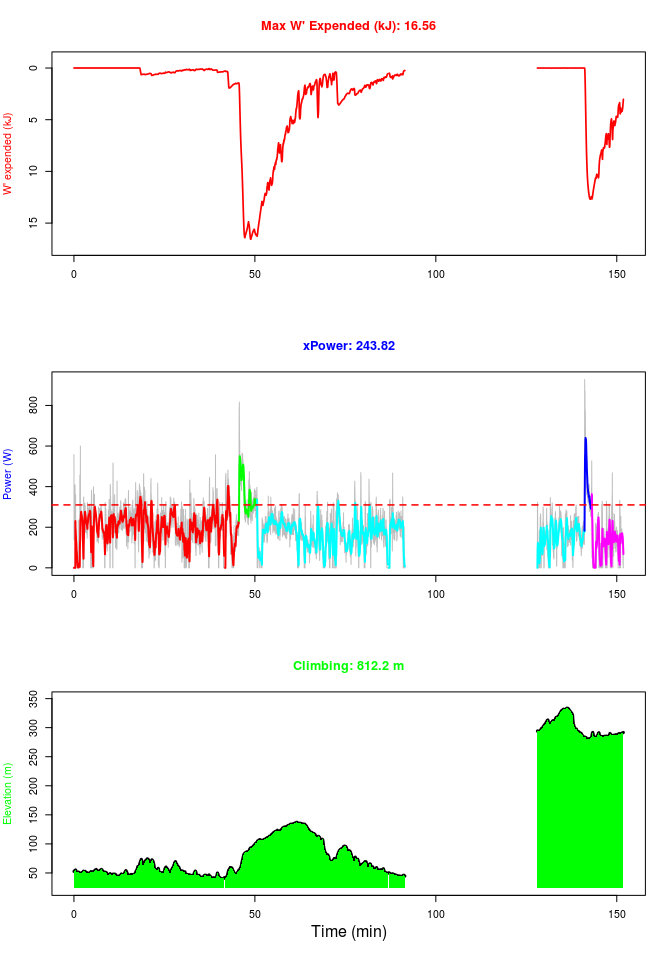

```r
plot(x = intervaldata,     # "x" is the data, for consistency with other methods.
     y = 1:3,              # Which plots should be created? see below.
     xvar = "timer.min",   # What should be plotted on the x axis?
     xlab = "Time (min)",  # x axis label.
     laps = TRUE,          # Should different laps be coloured?
     breaks = TRUE)        # Should stoppages in the ride be shown?
```

The `y` argument for this `plot` method specifies the way in which the plot stack should be generated. Specifically `length(y)` determines the number of plots to be stacked, and the combination of `c(1, 2, 3)` controls what is plotted and where. As is described in `?plot.cycleRdata`, numbers in this argument give:

1. A W’ balance plot (Skiba et al., 2012).
2. A power plot.
3. An elevation plot.

So for example:

```r
plot(intervaldata, y = c(3:1))  # Inverts the above plot.
plot(intervaldata, y = 2)       # Just plots power.
plot(intervaldata, y = c(1, 3)) # W' balance over elevation.
```

Plots can also be zoomed, and the title metric will be adjusted accordingly.

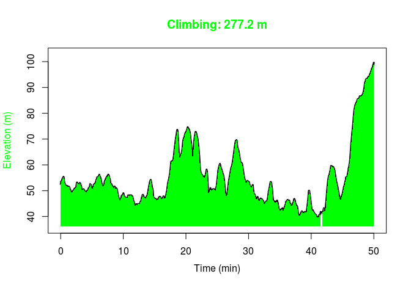

```r
## Zoom to 0-50 minutes.
plot(intervaldata, y = 3, xvar = "timer.min", xlim = c(0, 50))
```